# Plot

27 June, 2019

## Plots

## Plots

Plotting in R is easy:

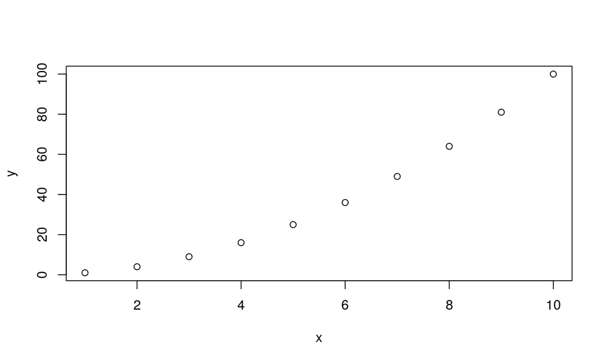

```r
x = 1:10
y = x**2
plot(x, y)
```

## Plot

Lets change color

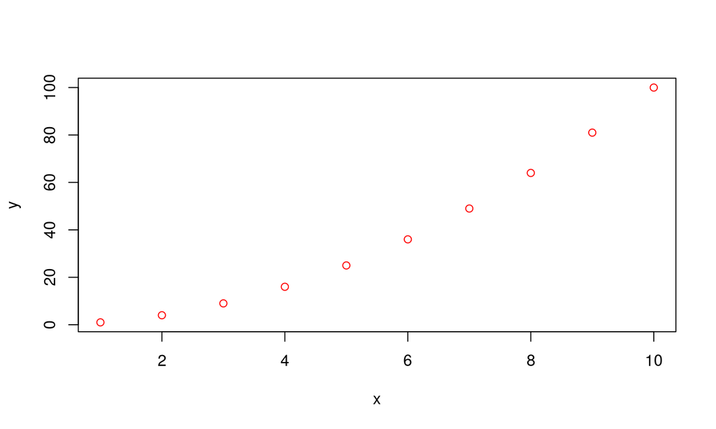

```r
plot(x, y, col = "red")
```

## Plot

Lets change point type

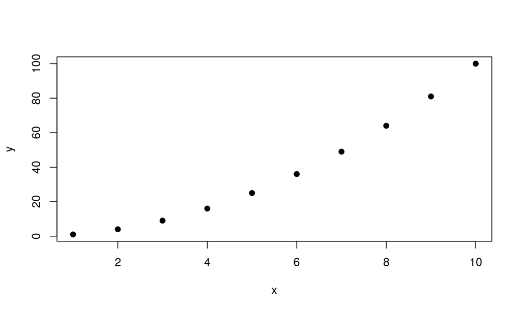

```r
plot(x, y, pch = 19)
```

## PCH

PCH (plotting character) is argument to specify point shapes

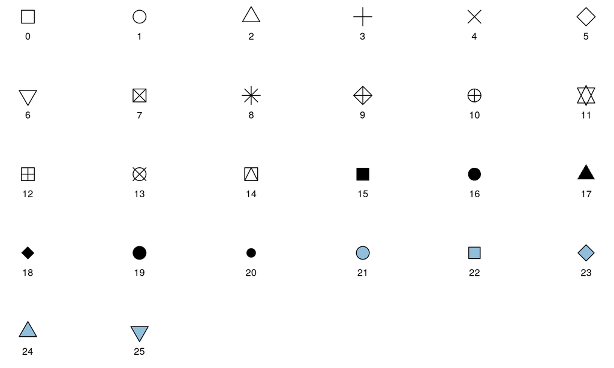

## PCH

[output not shown]

## Plot

- For PCH 21 to 25, background color can be specified

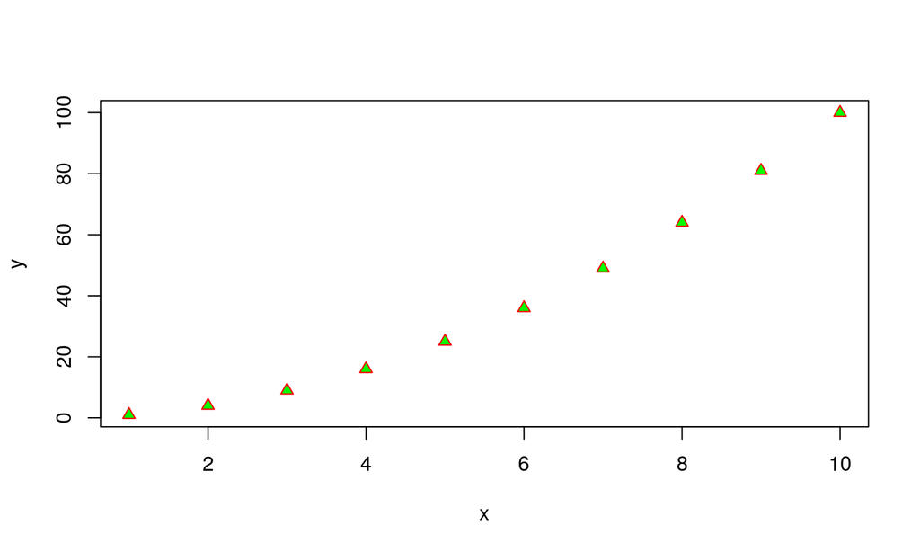

```r
plot(x, y, pch = 24, col="red", bg="green")
```

## Task

- plot data points in your favoriout color and shape

## Plot Line

The option `"type"` can change the plot type

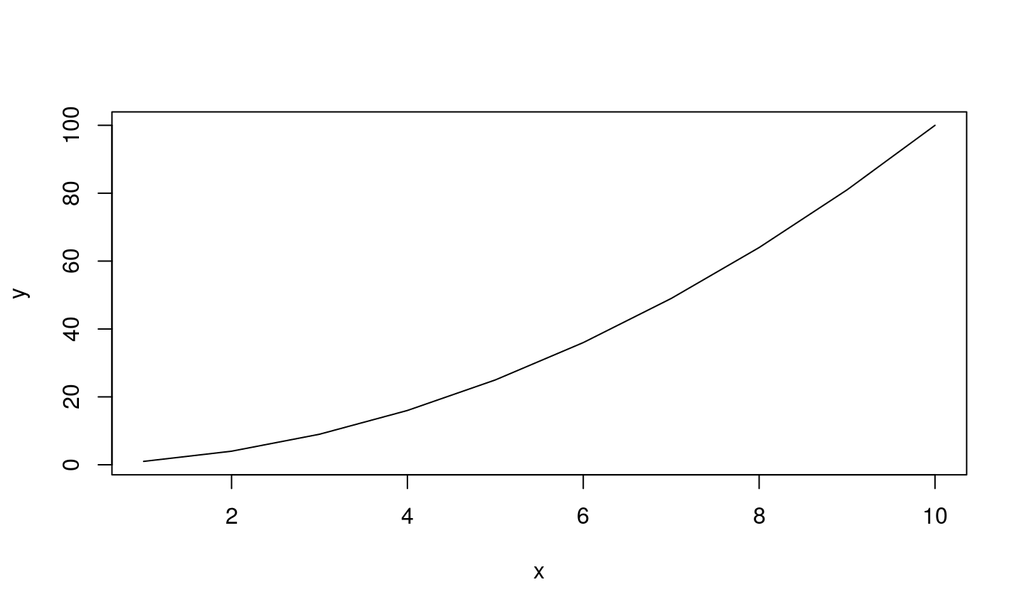

```r
plot(x, y, type = "l")
```

## Plot type

| “p” | for points |
| --- | --- |
| “l” | for lines |
| “b” | for both |
| “c” | for the lines part alone of “b” |
| “o” | for both ‘overplotted’ |
| “h” | for ‘histogram’ like (or ‘high-density’) vertical lines |
| “s” | for stair steps |
| “S” | for other steps |
| “n” | for no plotting |

## Plot

Lets plot both point and line

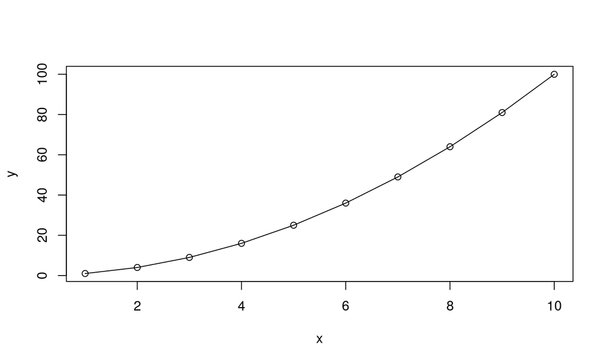

```r
plot(x, y, type = "o")
```

## Change line type

The option `"lty"` can change the line type

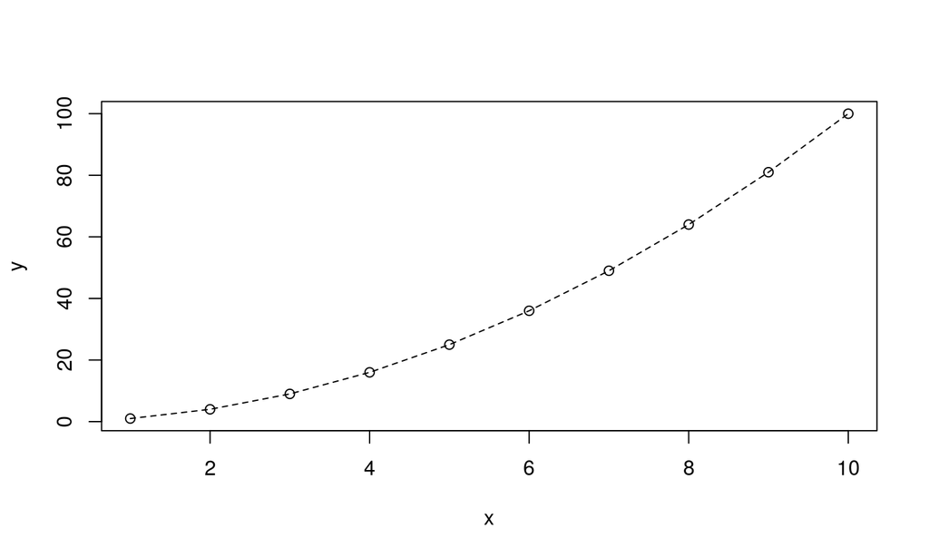

```r
plot(x, y, type = "o", lty=2)
```

## Line types in R

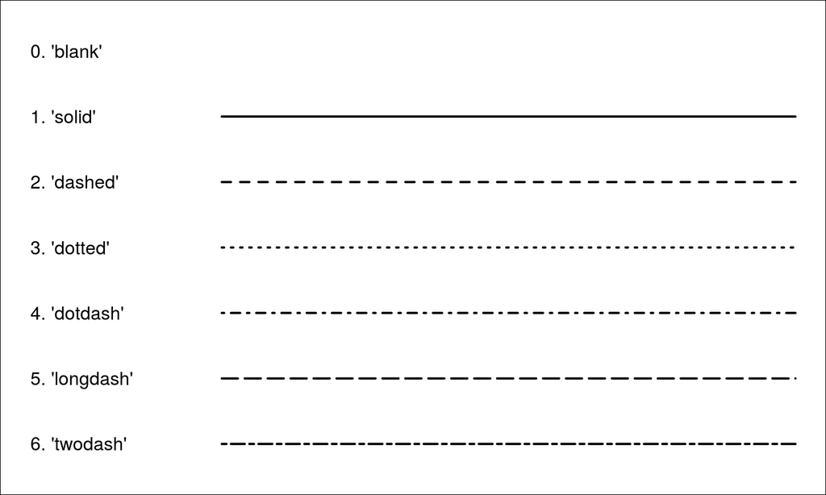

## Task

- plot data points and line in your favoriout color and shape

## Plot Title

Give plot a title

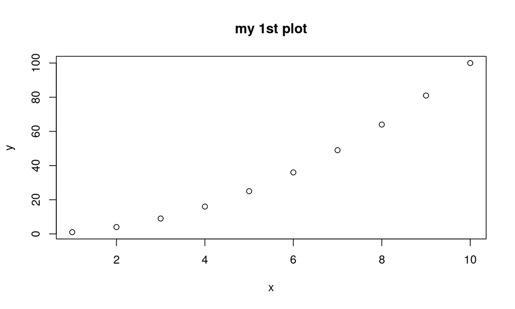

```r
plot(x, y, main = "my 1st plot")
```

## Axis Name

Change plot axis name

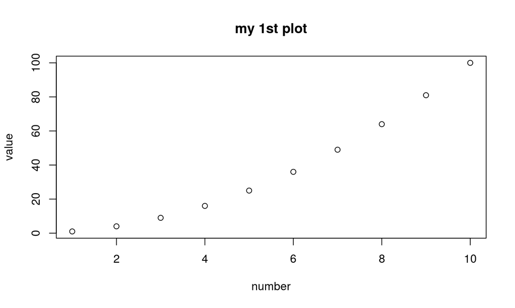

```r
plot(x, y, main = "my 1st plot", xlab = "number", ylab = "value")
```

## Adding more to a plot

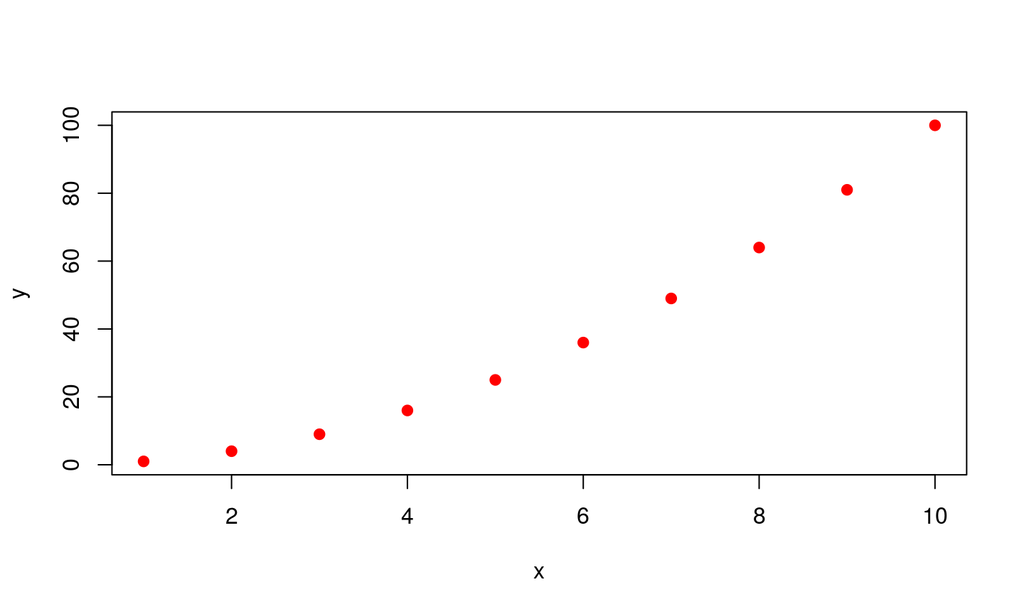

```r
x = 1:10
y = x**2
z = y + 1
plot(x, y, pch=19, col="red")
```

## Adding more to a plot

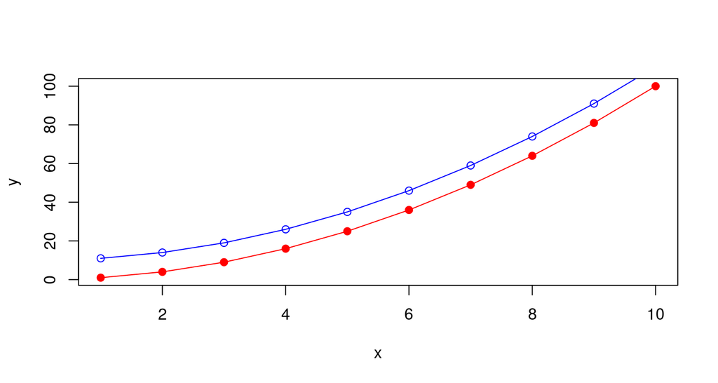

```r
x = 1:10
y = x**2
z = y + 10
plot(x, y, pch=19, col="red")
lines(x, y, col="red")
points(x, z, col="blue")
lines(x, z, col="blue")
```

## Task

- plot data points and line in your favoriout color and shape

## Fixing axis limits

- In R plots are static
- Adding new points can’t change the axis limits

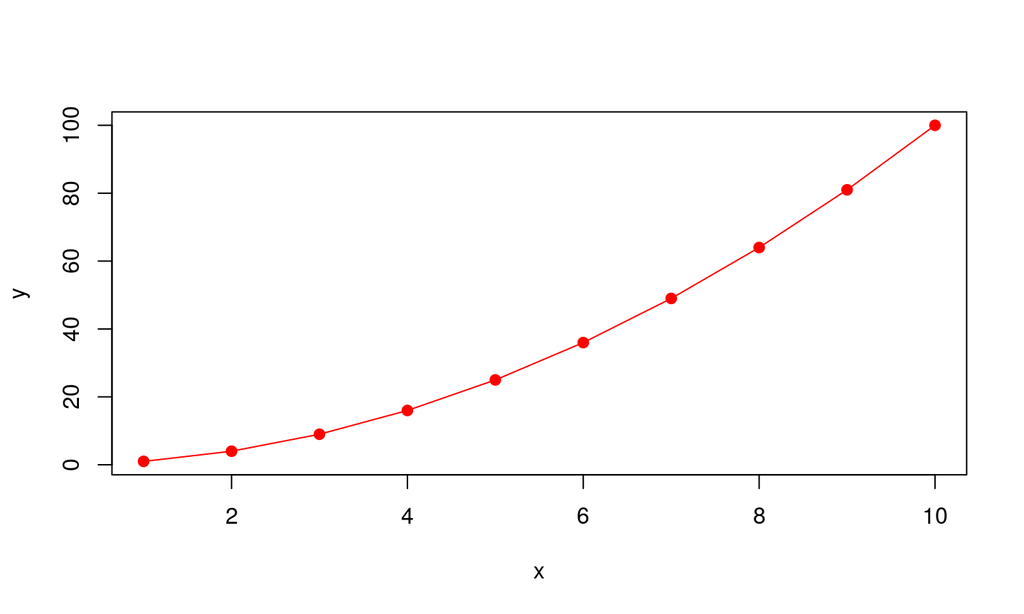

```r
plot(x, y, pch=19, col="red")
lines(x, y, col="red")
```

## Fixing axis limits

To overcome this issue specify the axis limits in advance

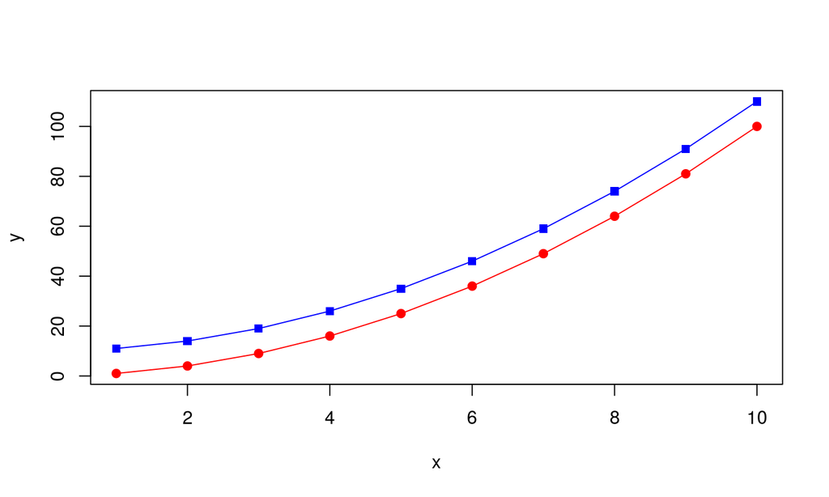

```r
ylimit = range(c(y,z))
plot(x, y, col="red", pch=19, ylim = ylimit)
lines(x, y, col="red")
points(x, z, col="blue", pch=15)
lines(x, z, col="blue")
```

## Adding legend

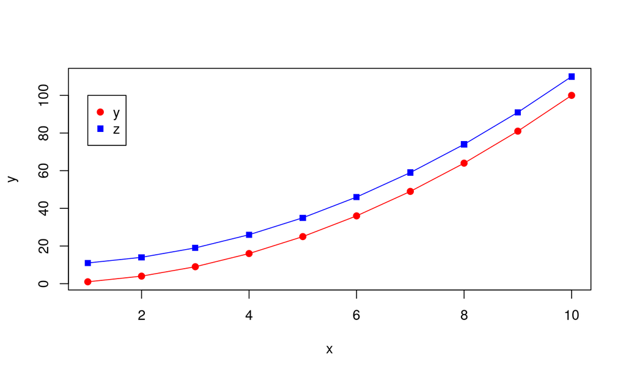

```r
plot(x, y, col="red", pch=19, ylim = c(1,110))
lines(x, y, col="red")
points(x, z, col="blue", pch=15)
lines(x, z, col="blue")
legend(1,100,legend=c("y","z"), col=c("red","blue"), pch=c(19,15))
```

## Barplot

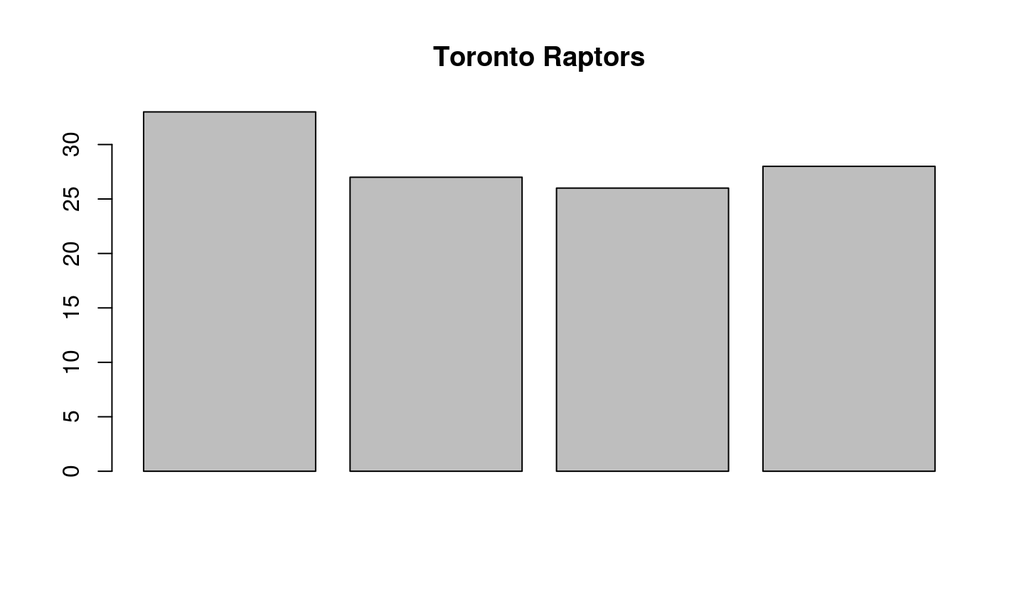

```r
raptors = c(33,27,26,28)
barplot(raptors, main="Toronto Raptors")
```

## How do we change the bar color?

## Barplot

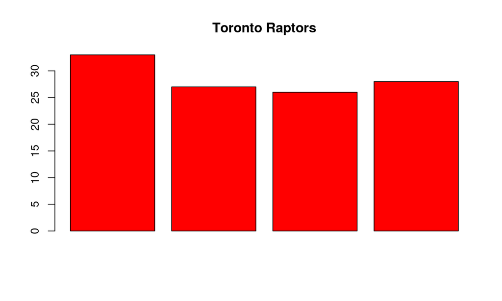

```r
raptors = c(33,27,26,28)
barplot(raptors, main="Toronto Raptors", col="red")
```

## How do we change border color?

## Barplot

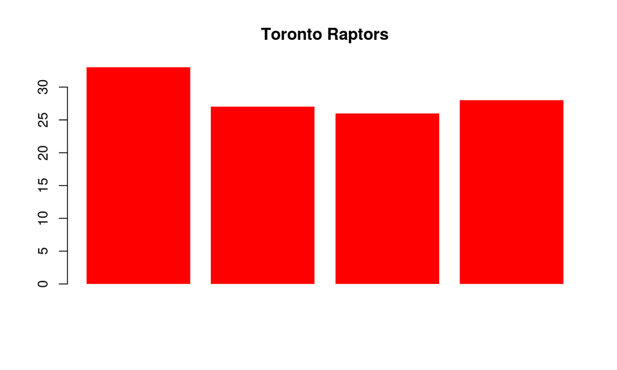

```r
raptors = c(33,27,26,28)
barplot(raptors, main="Toronto Raptors", col="red", border = NA)
```

## Barplot (Stacked)

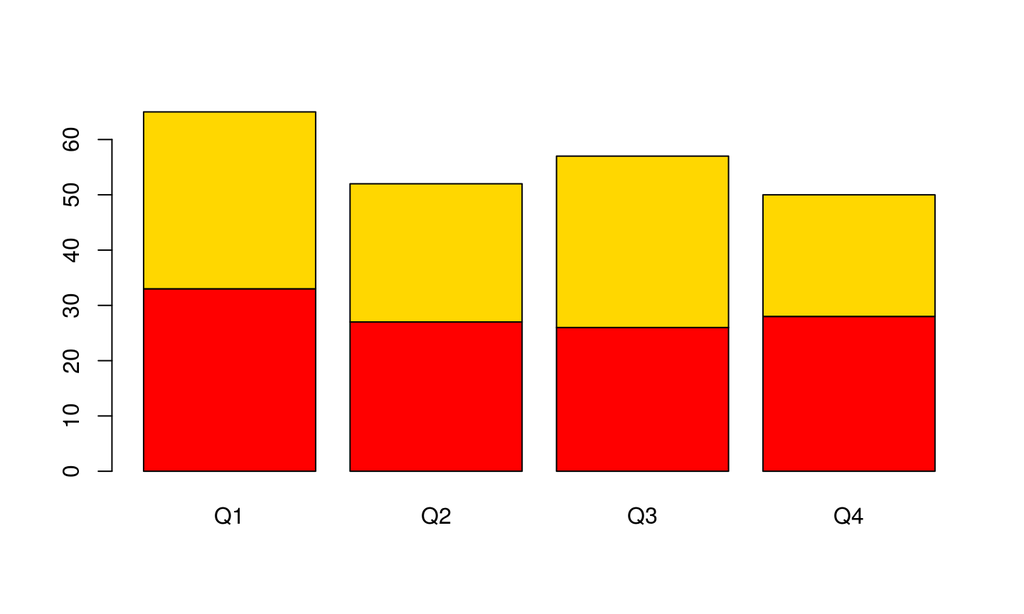

```r
raptors = c(33,27,26,28)
gsw = c(32, 25, 31, 22)
data = rbind(raptors, gsw)
colnames(data) = c("Q1", "Q2", "Q3", "Q4")
barplot(data, col=c("red", "gold"))
```

## Barplot (Grouped)

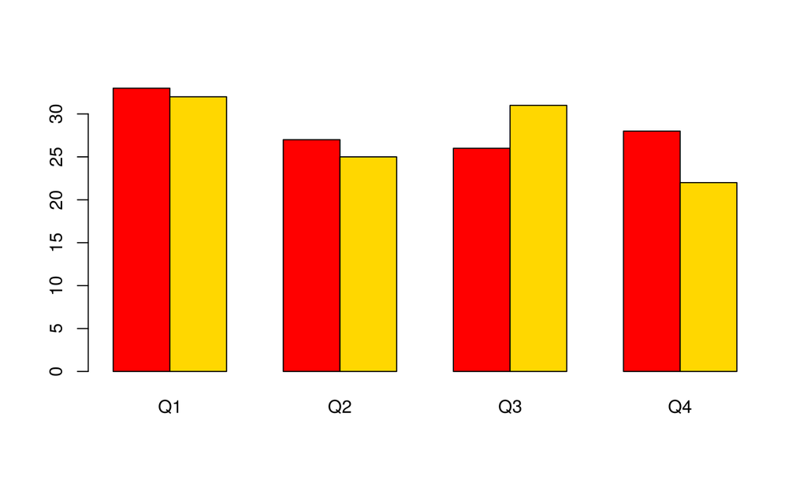

```r
barplot(data, col=c("red", "gold"), beside=TRUE)
```

## Barplot (add legend)

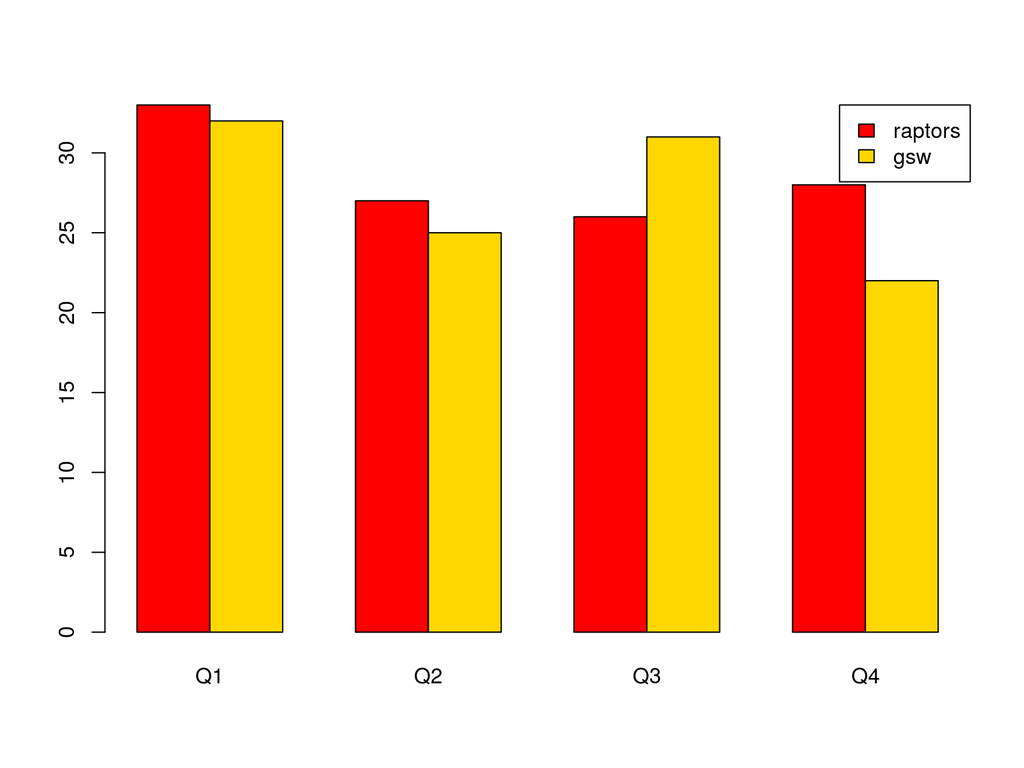

```r
barplot(data, col=c("red","gold"), beside=TRUE, legend=rownames(data),
        args.legend = list(x="topright"))
```

## Boxplot

## Boxplot

Same as barplot but data should be in column:

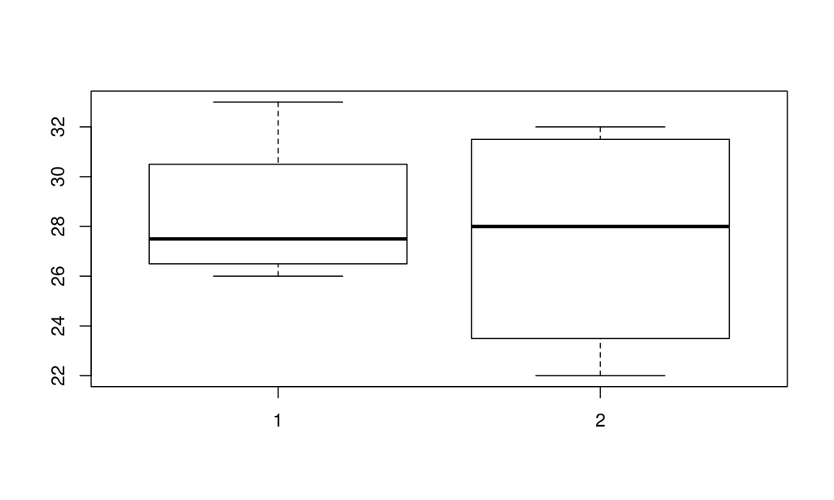

```r
raptors = c(33,27,26,28)
gsw = c(32, 25, 31, 22)
boxplot(raptors, gsw)
```

## Boxplot

Add names to the box:

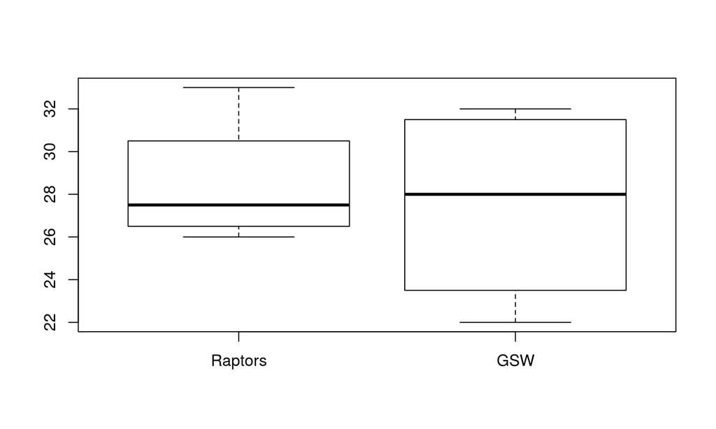

```r
raptors = c(33,27,26,28)
gsw = c(32, 25, 31, 22)
boxplot(raptors, gsw, names=c("Raptors","GSW"))
```

## Boxplot (color)

Here HTML color codes are used:

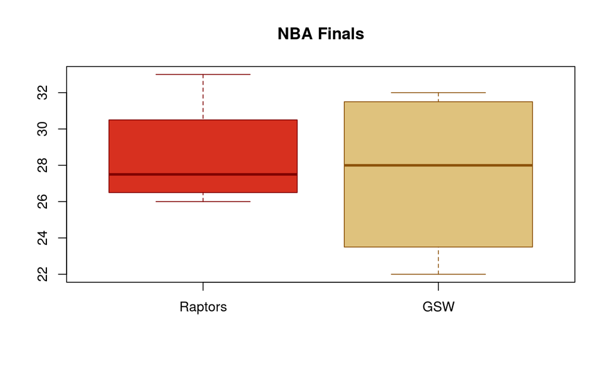

```r
boxplot(raptors, gsw, names=c("Raptors", "GSW"),
        col=c("#d7301f","#dfc27d"),
        border=c("#7f0000", "#8c510a"), main="NBA Finals")
```

## Task

- Add one more boxplot with data:

```r
bucks = c(23, 28, 25, 32)
```

## Using formula

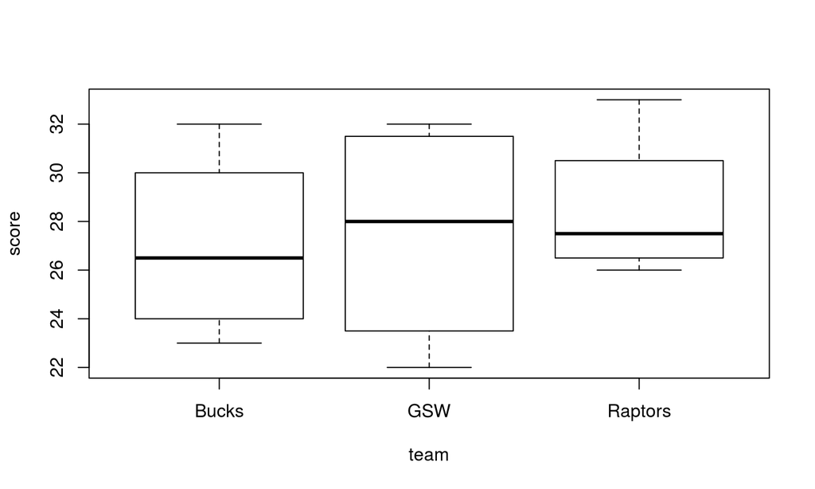

```r
bucks = c(23, 28, 25, 32)
df=data.frame(score=c(raptors, gsw, bucks),
              team= c(rep("Raptors", 4), rep("GSW", 4), rep("Bucks", 4)))
boxplot(score~team, data=df)
```

## Using formula

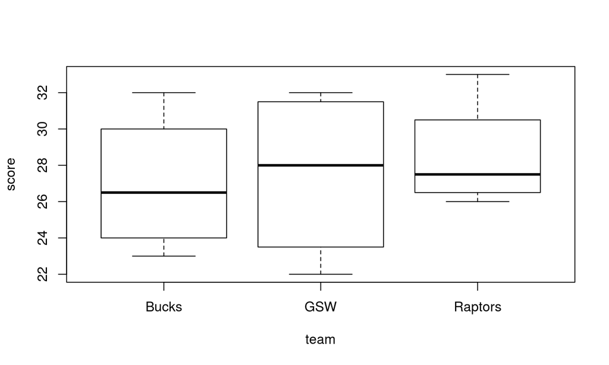

```r
bucks = c(23, 28, 25, 32)
df=data.frame(score=c(raptors, gsw, bucks),
              team=c(rep("Raptors",4), rep("GSW",4), rep("Bucks",4)))
boxplot(score~team, data=df)
```

## Saving Plots for Publication

- For publications use PDF or PNG format
- To save plot, open file just before plot function
- Don’t forget to close the file using **dev.off()**

```r
raptors = c(33,27,26,28)
gsw = c(32, 25, 31, 22)
bucks = c(23, 28, 25, 32)

pdf("NBA_finals.pdf", width = 4, height = 5)

boxplot(raptors, gsw, bucks, names=c("Raptors", "GSW", "Bucks"),
        col=c("#d7301f","#dfc27d", "#41ab5d"),
        border=c("#7f0000", "#8c510a", "#00441b"), main="NBA Finals")

dev.off()
```

## Saving Plots for Publication

- In **PNG** format, specify resolution using **res**
- **res** should be atleast 300 for publications and 600 for presenation
- Also don’t forget to specify **units**

```r
png("figure-1.png", width = 4, height = 5, units = 'in', res = 600)

boxplot(raptors, gsw, bucks, names=c("Raptors", "GSW", "Bucks"),
        col=c("#d7301f","#dfc27d", "#41ab5d"),
        border=c("#7f0000", "#8c510a", "#00441b"), main="NBA Finals")

dev.off()
```